# It Doesn’t Matter Who You Are: Make ’Em Laugh

Science Talk ’22

## Who Are We?

Sara ([@sarakyeo](https://twitter.com/sarakyeo)) is an Associate Professor of Science Communication at the University of Utah. She loves 🐱.

Amy ([@amybree](https://twitter.com/amybree)) is an Associate Professor of Communication at Loyola University Maryland. She studies political comedy 📺.

Mike ([@mcacciatore1981](https://twitter.com/mcacciatore1981)) is an Associate Professor of Public Relations at the University of Georgia. He is Co-Director of the Center for Health and Risk Communication at Grady College 🧬.

Ashley ([@a_a_anderson](https://twitter.com/a_a_anderson)) is an Associate Professor of Communication at Colorado State University. Her research examines communication around extreme weather events ☀️.

Kasha ([@KashaPatel](https://twitter.com/KashaPatel)) is a comedian and journalist. She is the deputy weather editor for the Capital Weather Gang at The Washington Post, covering weather, climate change and the environment. She is funny 😆.

## What Have We Studied?

In past research, we’ve looked at how scientists doing stand-up comedy can influence engagement with and perceptions of science.

[figure not shown]

[figure not shown]

## Then, we saw this in *Vanity Fair*…🤔

[figure not shown]

You can read this article [here](https://www.vanityfair.com/culture/2007/01/hitchens200701).

## And also this… 🤔

[figure not shown]

We read [an article about this study](https://www.psychologytoday.com/gb/blog/humor-sapiens/201910/are-men-really-funnier-women) that said men are funnier than women. But the first author is a man. So we just assumed he was joking the entire time.

## We wondered how this might affect scientists doing comedy

👩‍🔬 Specifically, we wondered whether audiences might perceive some scientists as more **funny** (and, therefore, more **warm** and **benevolent**) compared to others.

So…

We conducted a survey in which we embedded an experiment to examine how communicator characteristics (e.g. **gender**, **race**, and **credentials**) might impact how funny people thought they were and whether they were effective at communicating science!

## What Did We Do?

Kasha wrote an original 2-min stand-up set of science jokes and recruited four comedians to record it. 😄

Amy, Ashley, Mike, and Sara worked on creating a survey instrument. 📉

## We had 8 conditions in our experiment

1. White male comedian
2. White female comedian
3. Black male comedian
4. Black female comedian
5. White male scientist
6. White female scientist
7. Black male scientist
8. Black female scientist

## Respondents only saw one of the 8 conditions

There were only 4 comedians who recorded the jokes. 📽 And their scripts were identical.

To manipulate their credentials, we included a banner that identified the speaker as a **scientist** or a **comedian**.

Then, we asked them how funny they thought the speaker in the video was by asking them to self-report their experience of humor (*mirth*) and how effective they were at communicating science.

## There was little difference in mirth among conditions!

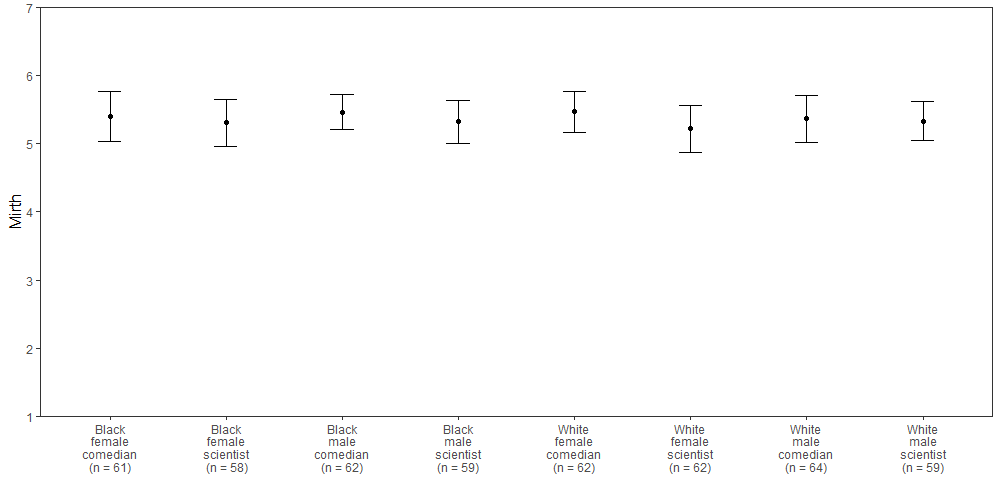

Mean and standard errors of mirth for each experimental condition.

## Although mirth was strongly associated with speaker effectiveness, a speaker’s **race** and **gender** did not affect speaker effectiveness.

## But…

### Speaker credentials moderated the influence of mirth on effectiveness

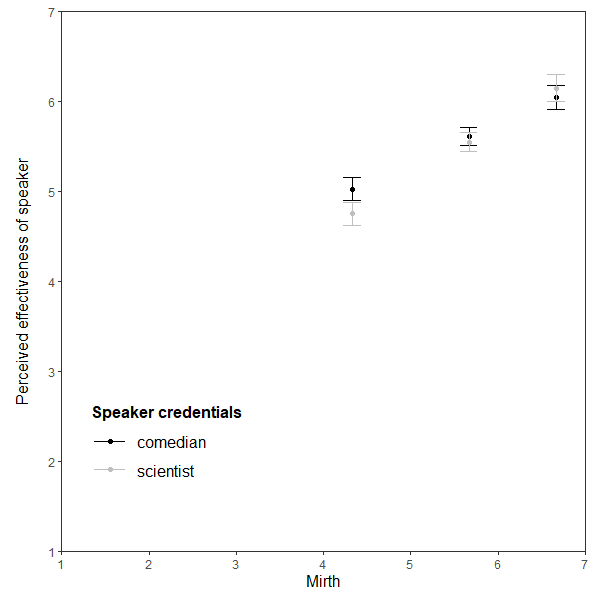

At low levels of mirth, scientists are perceived as less effective communicators.

But at higher levels of mirth, scientists are perceived to be as effective as comedians.

## So what?

## Humor as the equalizer of perceived communicator effectiveness

Comedians are perceived to be better communicators than scientists among respondents who reported lower levels of mirth. 🙀

Actually, this is not surprising when we consider warmth and the differences between scientists and comedians at connecting with audiences.

But if one can make an audience laugh, then perceptions of communicator effectiveness are higher, regardless of credentials. 😂

## 🔭 MAKE ’EM LAUGH! 😃

## Thank you!

Please connect with us–we’d love to hear from you!

Sara K. Yeo ([@sarakyeo](https://twitter.com/sarakyeo))

Amy B. Becker ([@amybree](https://twitter.com/amybree))

Mike A. Cacciatore ([@mcacciatore1981](https://twitter.com/mcacciatore1981))

Ashley A. Anderson ([@a_a_anderson](https://twitter.com/a_a_anderson))

Kasha Patel ([@KashaPatel](https://twitter.com/KashaPatel))